# Relatório 04 - Distribuição de probabilidade

Alex Gama

23/10/2024

# 1 Noções básicas

## 1.1 Objetivos

• Descrever sobre as distribuições continuas e discretas.

• Compreender a relação entre elas.

## 1.2 Introdução

Uma distribuição de probabilidade pé um modelo matemático que relaciona um certo valor da variável em estudo com a sua probabilidade de ocorrência.

Há dois tipos de distribuição de probabilidades:

Distribuições contínuas: Quando a variável que está sendo medida pe expressa em uma escala contínua, como no caso de uma característica dimensional.

Distribuições discretas: Quando a variável que está sendo medida só pode assumir certos valores, como por exemplo os valores inteiros: 0,1,2,etc.

# 2 Distribuição Geométrica

Várias tarefas, ou ações cotidianas são repetidas até que aquilo que desejamos ocorra (sucesso). Por exemplo, você pode ter de enviar uma mensagem diversas vezes até que o receptor efetivamente a receba – sucesso. Um problema como esse pode ser representado por uma distribuição geométrica. Quando você tiver interesse na probabilidade de um sucesso ocorrer em determinada tentativa x, a distribuição de probabilidades adequada será a distribuição discreta geométrica.

**Condições:**

A distribuição de probabilidade geométrica de uma variável aleatória x deve satisfazer às seguintes condições:

– A tentativa deve ser repetida até que um sucesso ocorra;

– Cada tentativa repetida é independente uma da outra;

– A probabilidade de sucesso p é a mesma para cada tentativa;

– A variável aleatória x representa o número de tentativas até ocorrer o primeiro sucesso.

**Função de probabilidade**

Assim, a probabilidade de que o primeiro sucesso ocorra considerando a tentativa número x é:

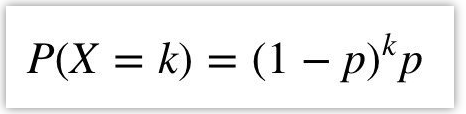

Sendo: K= número de tentativas p= probabilidade de sucesso

Exemplo:

Uma estatística precisa consultar informações públicas disponibilizadas em um site governamental que é protegido com um sistema de CAPTCHA. Para isso, ela programou um algoritmo baseado em OCR (optical character recognition) que resolve corretamente as CAPTCHAS com p = 0.5. Qual a probabilidade de quebrar a CAPTCHA na segunda tentativa?

# 3 Distribuição Hipergeométrica

Como em uma distribuição binomial, na distribuição hipergeométrica em cada tentativa a variável pode assumir os valores: sucesso e fracasso; porém, o experimento é realizado sem reposição, de forma distinta dos experimentos binomiais, nos quais qualquer amostragem deve ser feita com reposição, porque cada tentativa deve ser independente das outras.

**Função de probabilidade**

Pense em uma população composta por N elementos, dos quais uma quantidade r de elementos possui a característica A, e a quantidade N-r de elementos possui a característica B. Uma amostra de n elementos é escolhida ao acaso, sem reposição. Para calcular a probabilidade de que essa amostra contenha k elementos com a característica A, utilizando o princípio multiplicativo, você pode aplicar a equação:

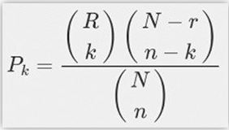

Em que max(0, n−N+r) ≤ k ≤ min(r, n). Os pares (k, p(k)) formam a distribuição hipergeométrica de probabilidades. Observação: Se você definir a variável aleatória X como sendo o número de elementos na amostra que possui a característica A, então P(X=k) = p(k).

**Exemplo**

Considere um problema de controle de qualidade, e suponha que para um lote de cem peças, dez sejam defeituosas. Qual a probabilidade de não se obter peças defeituosas escolhendo, aleatoriamente, cinco peças sem reposição? Solução: Nesse caso, N=100; r=10; n=5 e como queremos probabilidade de NÃO se obter peças defeituosas, temos que calcular p(0). Portanto, a probabilidade de não se obter peças defeituosas, nesse contexto, é de aproximadamente 58,38%.

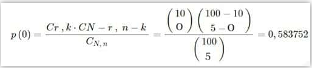

# 4 Distribuição Binomial Negativa

A distribuição binomial negativa descreve o número de falhas necessárias até que um número fixo de sucessos seja alcançado em uma série de ensaios independentes, cada um com a mesma probabilidade de sucesso.

## 4.1 Parâmetros:

- $r$: número fixo de sucessos desejados.
- $p$: probabilidade de sucesso em cada ensaio.

## 4.2 Função de probabilidade:

$$P(X = x) = \binom{x + r - 1}{r - 1} p^r (1 - p)^x, \quad x = 0, 1, 2, \dots$$
onde $x$ é o número de falhas observadas antes de atingir $r$ sucessos.

## 4.3 Exemplo de aplicação:

Usada em estudos de qualidade para modelar o número de defeitos encontrados até atingir um número mínimo de produtos aceitáveis.

# 5 Distribuição Multinomial

A distribuição multinomial é uma generalização da distribuição binomial para mais de duas categorias. Ela descreve os resultados de $n$ ensaios independentes, onde cada ensaio resulta em exatamente uma de $k$ categorias, com probabilidades associadas.

## 5.1 Parâmetros:

- $n$: número total de ensaios.
- $p_1, p_2, \dots, p_k$: probabilidades associadas às $k$ categorias (sendo $\sum_{i=1}^k p_i = 1$).

## 5.2 Função de probabilidade:

$$P(X_1 = x_1, X_2 = x_2, \dots, X_k = x_k) = \frac{n!}{x_1! x_2! \dots x_k!} p_1^{x_1} p_2^{x_2} \dots p_k^{x_k},$$
onde $x_1 + x_2 + \dots + x_k = n$ e $x_i$ é o número de vezes que a $i$-ésima categoria foi observada.

## 5.3 Exemplo de aplicação:

Utilizada em estudos de classificações, como pesquisas eleitorais em que se registram votos para vários candidatos.

# 6 Distribuição Uniforme

A distribuição uniforme descreve uma variável aleatória que tem a mesma probabilidade de assumir qualquer valor dentro de um intervalo definido.

## 6.1 Uniforme Discreta

Definida para um conjunto finito de valores igualmente espaçados.

### 6.1.1 Função de probabilidade:

$$P(X = x) = \frac{1}{n}, \quad x \in \{x_1, x_2, \dots, x_n\}.$$

## 6.2 Uniforme Contínua

Definida para intervalos contínuos de valores.

### 6.2.1 Função de densidade:

$$f(x) =
\begin{cases}
\frac{1}{b - a}, & \text{se } a \leq x \leq b, \\
0, & \text{caso contrário}.
\end{cases}$$
onde $a$ e $b$ são os limites do intervalo.

## 6.3 Exemplo de aplicação:

- **Discreta**: Lançamento de um dado justo, em que cada face tem a mesma probabilidade.
- **Contínua**: Gerar números aleatórios entre 0 e 1 para simulações computacionais.

# 7 Distribuição Exponencial

A distribuição exponencial é usada para modelar o tempo entre eventos em um processo de Poisson, onde os eventos ocorrem de forma contínua e independente.

## 7.1 Parâmetro:

- $\lambda$: taxa de ocorrência de eventos ($\lambda > 0$).

## 7.2 Função de densidade de probabilidade:

$$f(x) =
\begin{cases}
\lambda e^{-\lambda x}, & x \geq 0, \\
0, & x < 0.
\end{cases}$$

## 7.3 Propriedades:

- Esperança (média): $\mathbb{E}[X] = \frac{1}{\lambda}$.
- Variância: $\text{Var}(X) = \frac{1}{\lambda^2}$.

## 7.4 Exemplo de aplicação:

Modelagem de tempos de espera, como o tempo entre chegadas de clientes em um sistema de filas.

# 8 Distribuição Gama

A distribuição gama generaliza a distribuição exponencial e é usada para modelar somas de variáveis exponenciais independentes.

## 8.1 Parâmetros:

- $\alpha$: parâmetro de forma ($\alpha > 0$).
- $\beta$: parâmetro de escala ($\beta > 0$).

## 8.2 Função de densidade de probabilidade:

$$f(x) =
\begin{cases}
\frac{x^{\alpha - 1} e^{-x / \beta}}{\beta^\alpha \Gamma(\alpha)}, & x \geq 0, \\
0, & x < 0.
\end{cases}$$
onde $\Gamma(\alpha)$ é a função gama:
$$\Gamma(\alpha) = \int_0^\infty t^{\alpha - 1} e^{-t} \, dt.$$

## 8.3 Propriedades:

- Esperança (média): $\mathbb{E}[X] = \alpha \beta$.
- Variância: $\text{Var}(X) = \alpha \beta^2$.

## 8.4 Exemplo de aplicação:

Modelagem de tempos de vida, como o tempo até falha de um dispositivo eletrônico.

# 9 Distribuição Qui-Quadrado

A distribuição qui-quadrado ($\chi^2$) é uma distribuição de soma de quadrados de $k$ variáveis normais padrão independentes.

## 9.1 Parâmetro:

- $k$: graus de liberdade ($k > 0$).

## 9.2 Função de densidade de probabilidade:

$$f(x) =
\begin{cases}
\frac{x^{k/2 - 1} e^{-x/2}}{2^{k/2} \Gamma(k/2)}, & x \geq 0, \\
0, & x < 0.
\end{cases}$$

## 9.3 Propriedades:

- Esperança (média): $\mathbb{E}[X] = k$.
- Variância: $\text{Var}(X) = 2k$.

## 9.4 Exemplo de aplicação:

Usada em testes estatísticos, como o teste de ajuste ou independência.

# 10 Distribuição F

A distribuição F é usada para comparar variâncias em amostras independentes e é definida como a razão de duas variáveis qui-quadrado independentes, normalizadas pelos respectivos graus de liberdade.

## 10.1 Parâmetros:

- $d_1$: graus de liberdade do numerador.
- $d_2$: graus de liberdade do denominador.

## 10.2 Função de densidade de probabilidade:

$$f(x) =
\begin{cases}
\frac{\sqrt{\frac{(d_1 x)^{d_1} d_2^{d_2}}{(d_1 x + d_2)^{d_1 + d_2}}}}{x B\left(\frac{d_1}{2}, \frac{d_2}{2}\right)}, & x > 0, \\
0, & x \leq 0.
\end{cases}$$
onde $B(a, b)$ é a função beta.

## 10.3 Propriedades:

- Esperança (média): $\mathbb{E}[X] = \frac{d_2}{d_2 - 2}$ para $d_2 > 2$.
- Variância: $\text{Var}(X) = \frac{2d_2^2 (d_1 + d_2 - 2)}{d_1 (d_2 - 2)^2 (d_2 - 4)}$ para $d_2 > 4$.

## 10.4 Exemplo de aplicação:

Usada em análises de variância (ANOVA) para testar diferenças entre médias de grupos.